# stGradient End-to-End Workflow

This vignette demonstrates how to run the main stGradient workflows on the included demo Seurat object. Use the tabs below to navigate between sections.

# Sections

## Setup

Load packages and the demo Seurat object.

```r
library(stGradient)
library(Seurat)
library(dplyr)
library(ggplot2)

# Locate demo data both when developing and when installed.
demo_path <- system.file("demoData", "ps20_27981.rds", package = "stGradient")
if (demo_path == "") demo_path <- file.path("demoData", "ps20_27981.rds")
if (!file.exists(demo_path)) demo_path <- file.path("..", "demoData", "ps20_27981.rds")
stopifnot(file.exists(demo_path))

obj <- load_xenium_seurat(
  rds_path = demo_path,
  celltype_col = "singleR.predicted.id.brcaAtlas"
)
```

## 1) Polygons & Boundaries

Build DBSCAN tumor polygons, label each cell as inside/outside, and compute signed boundary distances.

```r
# Add a broad cancer flag if it does not already exist.
if (!"is_cancer" %in% colnames(obj@meta.data)) {
  ct <- as.character(obj$singleR.predicted.id.brcaAtlas)
  obj$is_cancer <- grepl("Cancer|Tumor|Malignant", ct, ignore.case = TRUE)
}

# If the heuristic yields too few cancer cells, use a fallback based on top niche labels.
if (sum(obj$is_cancer, na.rm = TRUE) < 100) {
  obj$is_cancer <- obj$singleR.predicted.id.brcaAtlas %in% names(sort(table(obj$singleR.predicted.id.brcaAtlas), decreasing = TRUE))[1:2]
}

# Build polygons and add inside/outside membership.
auto_polygons <- plot_dbscan_polygons(obj, plot = FALSE)
obj <- add_polygon_membership(obj, auto_polygons)
obj$boundary_distance <- calculate_boundary_distances(obj, auto_polygons)

table(obj$inside_polygon)
```

```
#>
#> FALSE  TRUE
#> 40400  2941
```

## 2) Distance Profile

Calculate transcriptomic and compositional separation metrics at increasing distances from the tumor boundary.

```r
res <- calculate_distance_profile(
  seurat_obj = obj,
  distance_thresholds = seq(25, 125, by = 25),
  metric = "all",
  group_by = "singleR.predicted.id.brcaAtlas",
  inside_mode = "distance"
)
```

```
#> Processing distance: 25 μm (inside_mode = 'distance')
#>   Inside cells: 1727, Outside cells: 1487
#> Processing distance: 50 μm (inside_mode = 'distance')
#>   Inside cells: 2435, Outside cells: 2551
#> Processing distance: 75 μm (inside_mode = 'distance')
#>   Inside cells: 2758, Outside cells: 3581
#> Processing distance: 100 μm (inside_mode = 'distance')
#>   Inside cells: 2893, Outside cells: 4753
#> Processing distance: 125 μm (inside_mode = 'distance')
#>   Inside cells: 2941, Outside cells: 6023
```

```r
head(res$profile)
```

```
#>   distance n_inside n_outside inside_mode composition_difference
#> 1       25     1727      1487    distance             0.07355763
#> 2       50     2435      2551    distance             0.11494737
#> 3       75     2758      3581    distance             0.14316498
#> 4      100     2893      4753    distance             0.16481349
#> 5      125     2941      6023    distance             0.18208696
#>   transcriptomic_distance de_strength
#> 1              0.09202439    8.493778
#> 2              0.24079706    8.097392
#> 3              0.36611357    8.223527
#> 4              0.46965185    8.466384
#> 5              0.54871978    8.724195
```

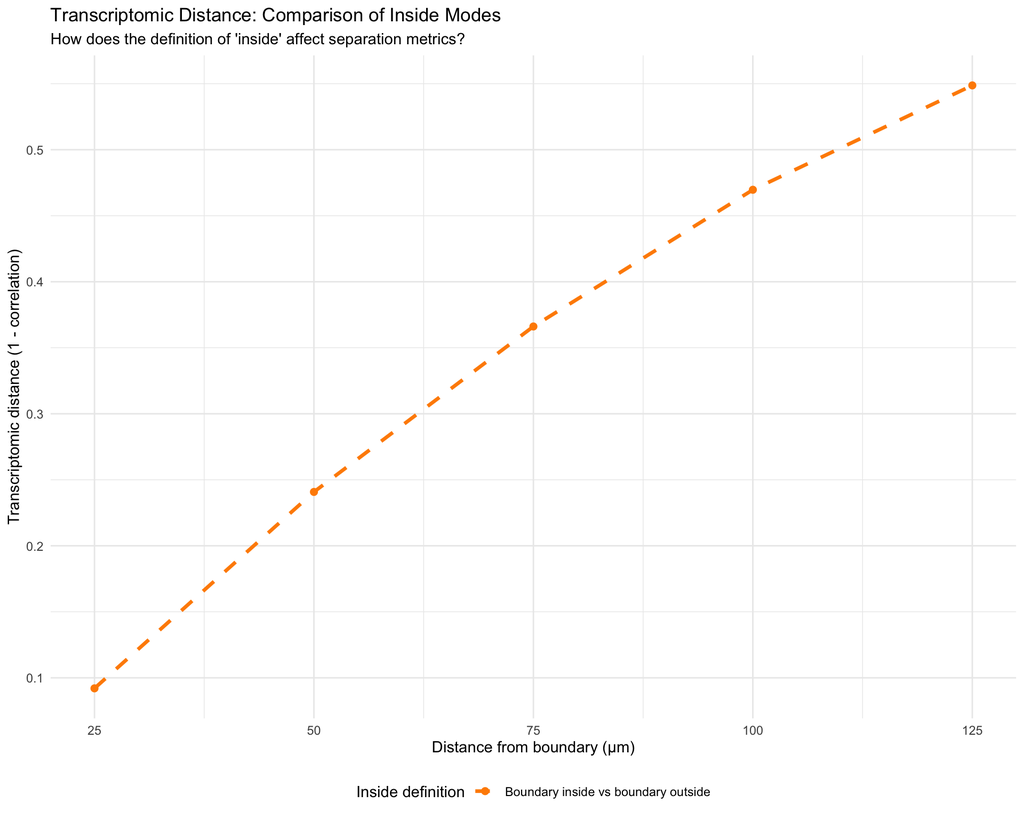

```r
plot_distance_comparison(res$profile)
```

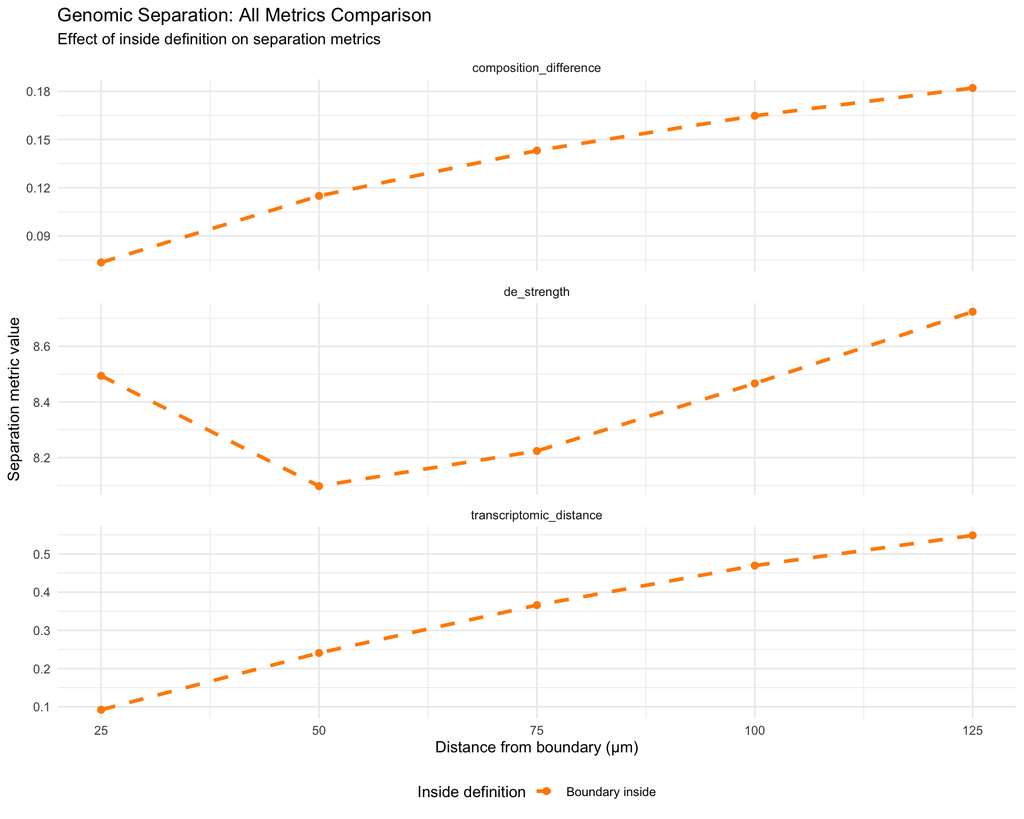

```r
plot_all_metrics(res$profile)
```

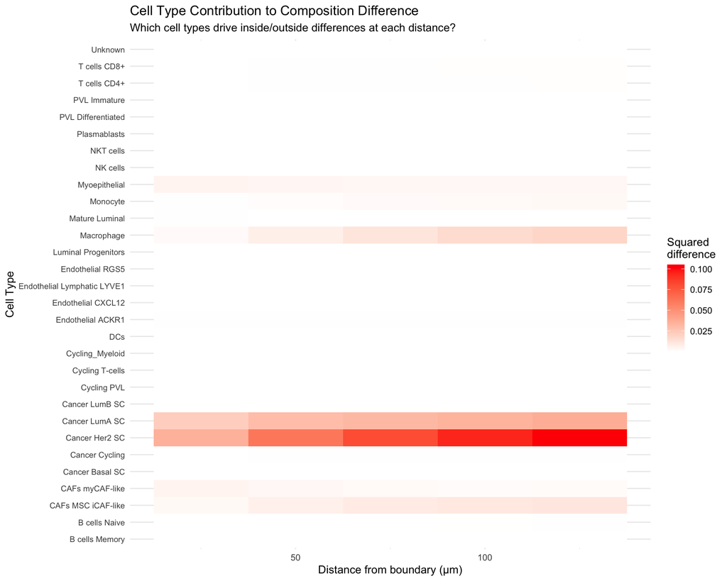

```r
plot_celltype_heatmap(res$celltype_contributions)
```

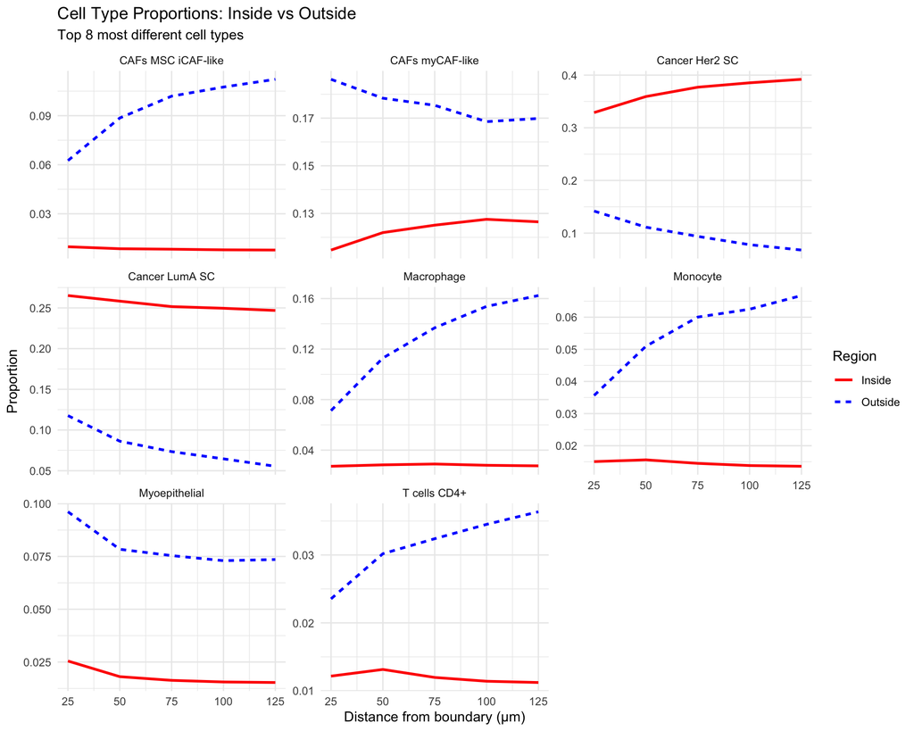

```r
plot_celltype_proportions(res$celltype_contributions, top_n = 8)
```

## 3) ROI QC

Visualize spatial ROI membership and cell type composition inside versus outside the tumor polygon.

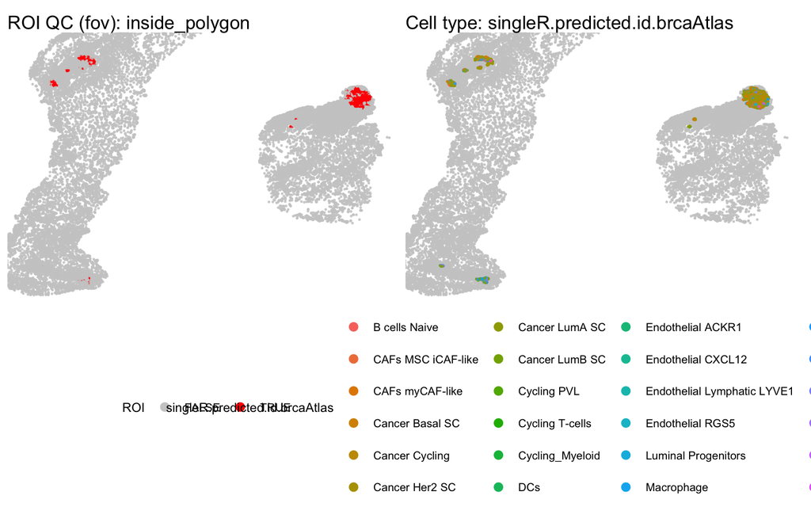

```r
qc_out <- qc_plot_xenium(
  obj = obj,
  roi_col = "inside_polygon",
  celltype_col = "singleR.predicted.id.brcaAtlas",
  show = "both",
  zoom = TRUE,
  grey_outside_roi = TRUE
)

qc_out$p
```

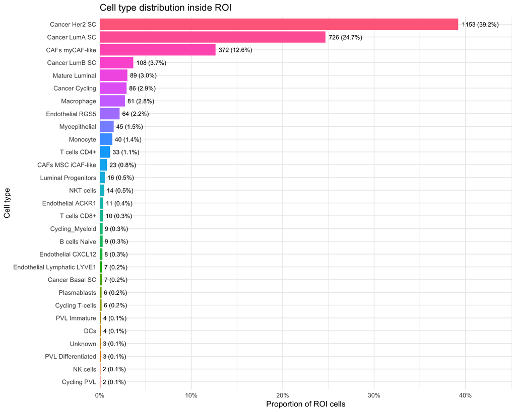

```r
plot_roi_celltype_dist(
  df = qc_out$df,
  roi_col = "inside_polygon",
  celltype_col = "singleR.predicted.id.brcaAtlas",
  metric = "proportion",
  labels = "both"
)
```

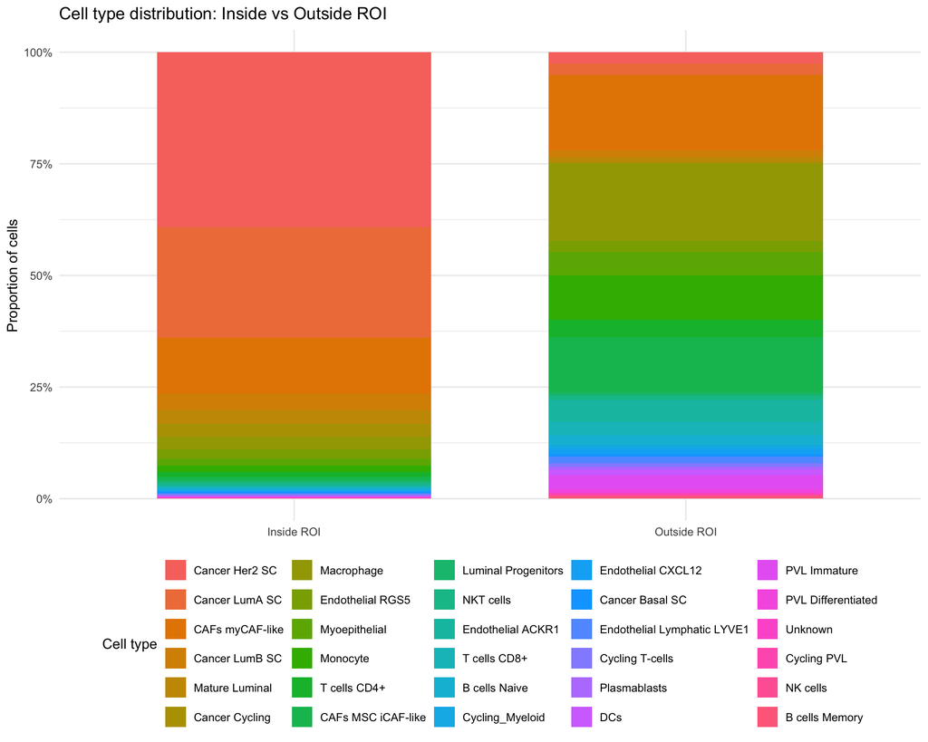

```r
plot_roi_inout_celltype_stack(
  df = qc_out$df,
  roi_col = "inside_polygon",
  celltype_col = "singleR.predicted.id.brcaAtlas",
  metric = "proportion"
)
```

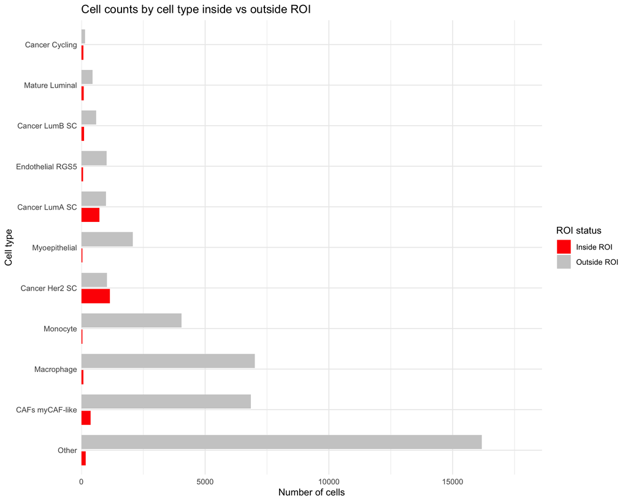

```r
plot_roi_inout_celltype_dodge(
  df = qc_out$df,
  roi_col = "inside_polygon",
  celltype_col = "singleR.predicted.id.brcaAtlas",
  metric = "count",
  top_n = 10,
  top_n_by = "inside"
)
```

## 4) PCF Analysis

Compute pair correlation functions (PCF) for all cell-type pairs using only cells outside the tumor polygon.

```r
pcf_summary <- calculate_pcf_outside_summary(
  seurat_obj = obj,
  polygons = auto_polygons,
  distance = 100,
  min_cells = 50,
  celltype_col = "singleR.predicted.id.brcaAtlas",
  include_self_pairs = TRUE,
  ordered_pairs = FALSE,
  show_progress = FALSE
)

head(pcf_summary)
```

```
#>                type1              type2   g_value n_type1 n_type2
#> 1     B cells Memory     B cells Memory 32.067101     226     226
#> 2      B cells Naive      B cells Naive 21.957555     919     919
#> 3 CAFs MSC iCAF-like CAFs MSC iCAF-like  9.035418    5040    5040
#> 4    CAFs myCAF-like    CAFs myCAF-like 13.639235    6846    6846
#> 5    Cancer Basal SC    Cancer Basal SC 12.972590     233     233
#> 6     Cancer Cycling     Cancer Cycling 12.299326     142     142
```

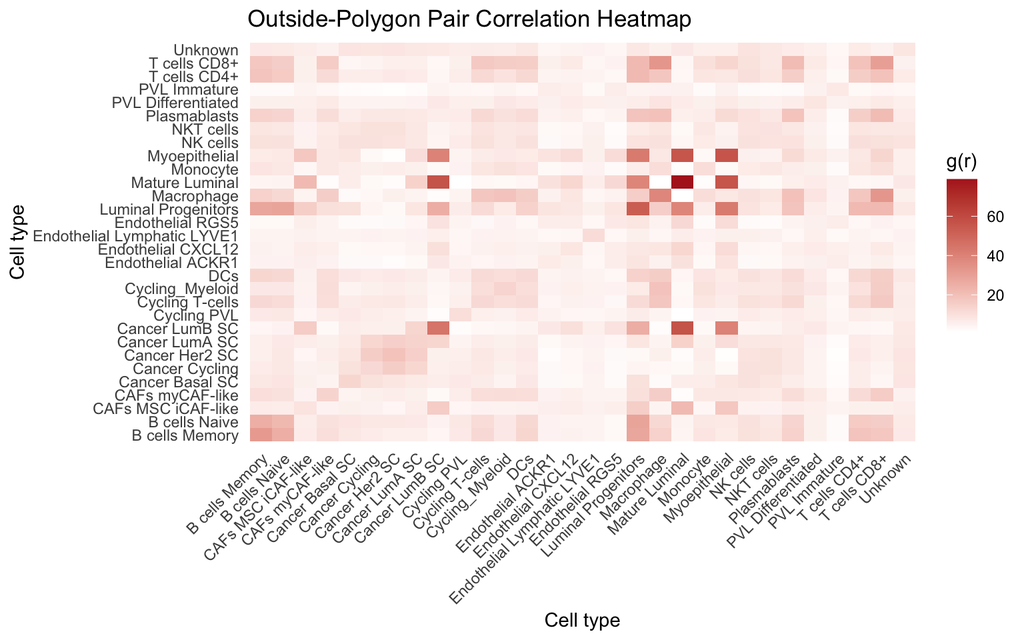

```r
plot_pcf_outside_heatmap(pcf_summary, midpoint = 1)
```

### Pair envelopes: T Cells CD8+ vs Cancer LumB SC

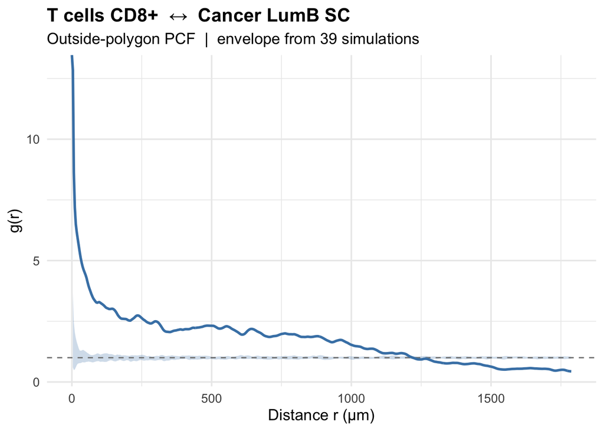

```r
plot_pcf_pair_gg(
  seurat_obj = obj,
  polygons = auto_polygons,
  type1 = "T cells CD8+",
  type2 = "Cancer LumB SC",
  celltype_col = "singleR.predicted.id.brcaAtlas",
  min_cells = 10,
  nsim = 39,
  bw = 10
)
```

### Pair envelopes: B Cells Memory vs B Cells Naive

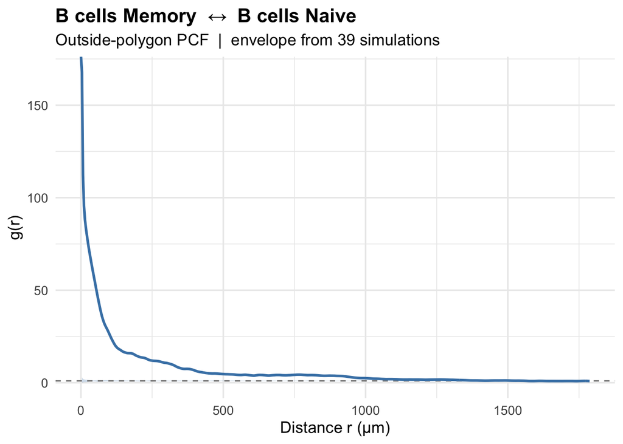

```r
plot_pcf_pair_gg(
  seurat_obj = obj,
  polygons = auto_polygons,
  type1 = "B cells Memory",
  type2 = "B cells Naive",
  celltype_col = "singleR.predicted.id.brcaAtlas",
  min_cells = 10,
  nsim = 39,
  bw = 10
)
```

```r
# Full envelope run for all pairs (slow; saves to PDF).
env_list <- plot_pcf_outside_pair_envelopes(
  seurat_obj = obj,
  polygons = auto_polygons,
  celltype_col = "singleR.predicted.id.brcaAtlas",
  min_cells = 50,
  include_self_pairs = FALSE,
  ordered_pairs = FALSE,
  nsim = 39,
  bw = 10,
  file = "pcf_outside_pairs.pdf"
)
```

## 5) Boundary Distance Genes

Identify genes whose expression varies systematically with distance from the tumor boundary.

```r
obj <- compute_distance_from_boundary(
  obj,
  polygon_col = "inside_polygon",
  intratumoral_label = TRUE,
  fov_name = "fov"
)

dist_res <- find_distance_associated_genes(
  seurat_obj = obj,
  assay = "Xenium",
  focus = "peritumoral",
  min_cells_expressing = 50,
  n_distance_bins = 8,
  max_dist_quantile = 0.95,
  p_adj_threshold = 0.05
)

if (!is.null(dist_res)) {
  head(dist_res$results)
}
```

```r
if (!is.null(dist_res)) {
  dist_plots <- plot_distance_genes(dist_res, top_n = 12, sample_label = "Demo")
  print(dist_plots$volcano)
  if (!is.null(dist_plots$trends)) print(dist_plots$trends)
}
```

## 6) T-cell Hotspots

Detect intratumoral CD4+/CD8+ T-cell clusters (hotspots) and find genes associated with distance from those hotspots.

```r
hs <- define_tcell_hotspots(
  seurat_obj = obj,
  celltype_col = "singleR.predicted.id.brcaAtlas",
  tcell_labels = c("T Cells CD4+", "T Cells CD8+"),
  polygon_col = "inside_polygon",
  intratumoral_label = TRUE,
  eps = 50,
  min_pts = 10,
  min_hotspot_size = 5
)

if (!is.null(hs)) {
  plot_tcell_hotspots(obj, hs, celltype_col = "singleR.predicted.id.brcaAtlas")
}
```

```r
if (!is.null(hs)) {
  hs_res <- find_hotspot_distance_genes(
    seurat_obj = obj,
    hotspot_result = hs,
    assay = "Xenium",
    focus = "perihotspot",
    min_cells_expressing = 50,
    n_distance_bins = 8,
    max_dist_quantile = 0.95,
    p_adj_threshold = 0.05,
    exclude_tcell_labels = c("T Cells CD4+", "T Cells CD8+"),
    celltype_col = "singleR.predicted.id.brcaAtlas"
  )

  if (!is.null(hs_res)) head(hs_res$results)
}
```

## 7) Niche Analysis

Run the spatial niche pipeline on pseudo-samples derived from the demo object to demonstrate the pCR cohort workflow.

The pCR niche functions are designed for multi-sample cohorts. This demo creates pseudo-samples from the single object only to show function usage.

```r
set.seed(42)
all_cells <- colnames(obj)
patient_ids <- c("demo_A", "demo_B", "demo_C", "demo_D")

split_idx <- split(sample(all_cells), rep(patient_ids, each = floor(length(all_cells) / length(patient_ids))))

seurat_list <- lapply(patient_ids, function(pid) subset(obj, cells = split_idx[[pid]]))
names(seurat_list) <- patient_ids

pcr_status <- data.frame(
  patient_id = patient_ids,
  pCR = c(1L, 0L, 1L, 0L),
  stringsAsFactors = FALSE
)

all_celltypes <- sort(unique(as.character(obj$singleR.predicted.id.brcaAtlas)))
all_celltypes <- all_celltypes[!grepl("^\\d+$", all_celltypes)]
```

```r
intra <- run_niche_pipeline(
  seurat_list = seurat_list,
  subset_value = TRUE,
  pcr_status = pcr_status,
  all_celltypes = all_celltypes,
  celltype_col = "singleR.predicted.id.brcaAtlas",
  polygon_col = "inside_polygon",
  k = 10,
  n_niches = 4
)

intra_niches <- setdiff(colnames(intra$niche_prop_df), c("patient_id", "pCR"))
intra_X <- as.matrix(intra$niche_prop_df[, intra_niches, drop = FALSE])
intra_y <- intra$niche_prop_df$pCR

stat_intra <- run_niche_stat_tests(intra_X, intra_y, intra_niches, n_perm = 100)
lr_intra <- run_niche_univariate_lr(intra_X, intra_y, intra_niches)

head(stat_intra)
```

```
#>                                    niche   mean_pCR mean_non_pCR        diff
#> 1  Cancer Her2 SC + Cancer LumA SC niche 0.40148473   0.36581125  0.03567348
#> 2  Cancer LumA SC + Cancer Her2 SC niche 0.26565486   0.28129224 -0.01563738
#> 3  Mature Luminal + Cancer LumB SC niche 0.07261536   0.08423806 -0.01162270
#> 4 Cancer Her2 SC + CAFs myCAF-like niche 0.26024505   0.26865845 -0.00841340
#>    wilcox_p    perm_p           direction wilcox_padj perm_padj
#> 1 0.2452781 0.2376238     enriched in pCR   0.9313805  0.950495
#> 2 0.6985354 0.7128713 enriched in non-pCR   0.9313805  0.990099
#> 3 0.6985354 0.7425743 enriched in non-pCR   0.9313805  0.990099
#> 4 1.0000000 1.0000000 enriched in non-pCR   1.0000000  1.000000
```

```r
head(lr_intra)
```

```
#>                                    niche   estimate    std_error       z_value
#> 1  Mature Luminal + Cancer LumB SC niche -120.05364 1.301685e+02 -0.9222941325
#> 2  Cancer LumA SC + Cancer Her2 SC niche  -27.19081 4.383305e+01 -0.6203265336
#> 3 Cancer Her2 SC + CAFs myCAF-like niche  -15.40159 4.376268e+01 -0.3519343592
#> 4  Cancer Her2 SC + Cancer LumA SC niche 2915.97860 6.165827e+06  0.0004729258
#>     p_value   odds_ratio         direction     p_adj
#> 1 0.3563752 7.267194e-53 higher in non-pCR 0.9665167
#> 2 0.5350428 1.553042e-12 higher in non-pCR 0.9665167
#> 3 0.7248875 2.047266e-07 higher in non-pCR 0.9665167
#> 4 0.9996227          Inf     higher in pCR 0.9996227
```

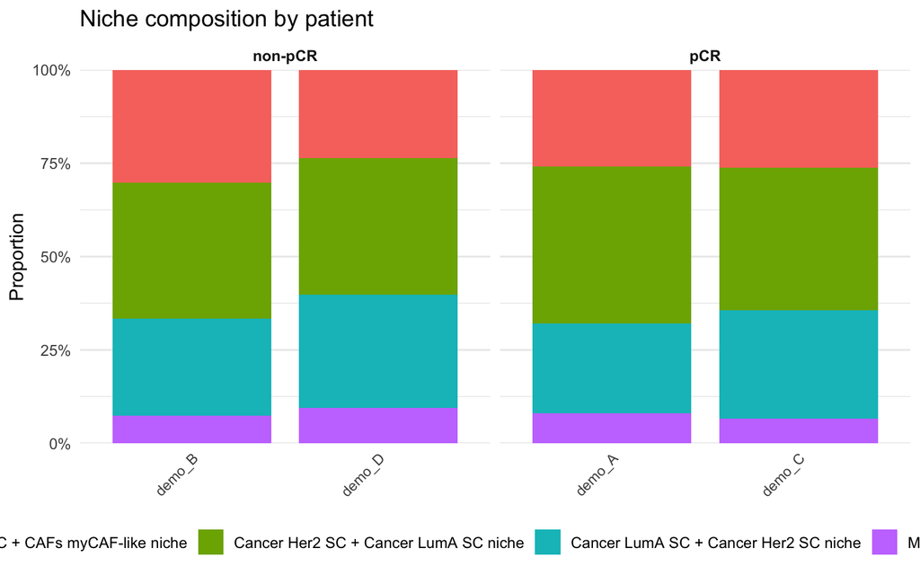

```r
plot_niche_stacked_composition(intra$niche_prop_df)
```

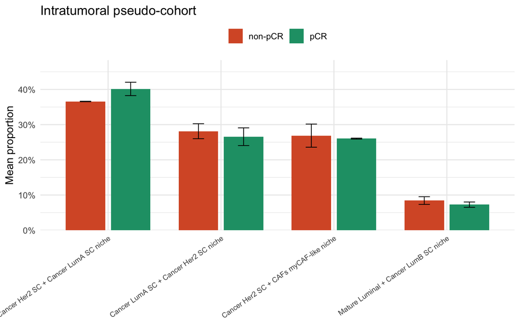

```r
plot_niche_grouped_bars(stat_intra, intra_X, intra_y, intra_niches, title = "Intratumoral pseudo-cohort")
```

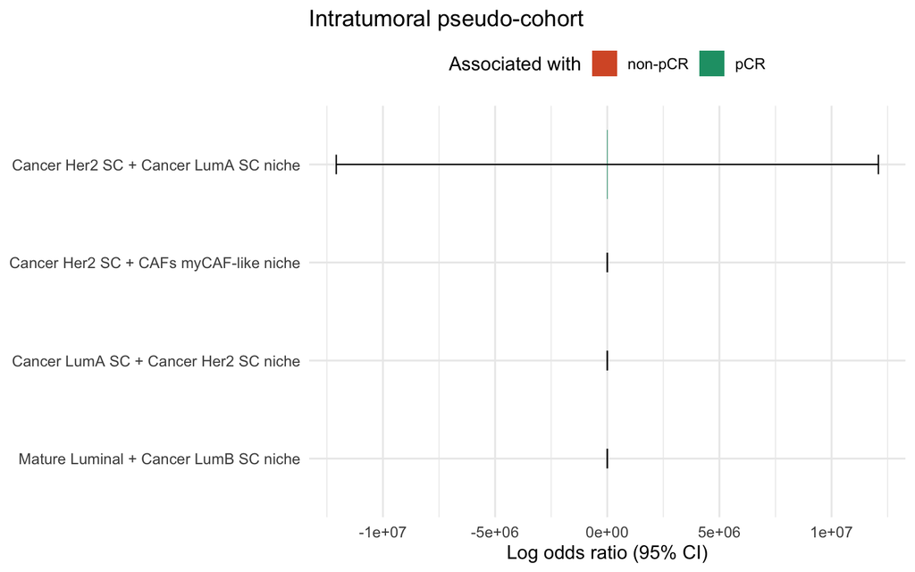

```r
plot_niche_coefficients(lr_intra, title = "Intratumoral pseudo-cohort")
```

## Interactive App

Launch the Shiny app for interactive polygon drawing on your own data.

```r
# Interactive polygon drawing app (manual usage)
launch_stGradient()
```